# 03_arc_len_frm_intrr_ang

## 03_arc_len_frm_intrr_ang

#### Question

1. A length of red string is pulled around the circle with radius $r=3$. The red string [subtends](https://en.wikipedia.org/wiki/Subtended_angle) a [central angle](https://en.wikipedia.org/wiki/Central_angle) with a degree measure of $\psi$°, and the red string also subtends an **[inscribed angle](https://en.wikipedia.org/wiki/Inscribed_angle)** with degree measure of 87°.

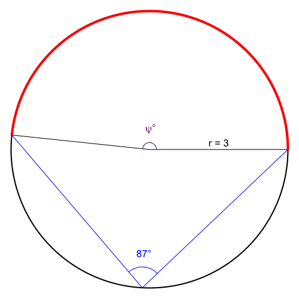

   How long, in centimeters, is the red string? Please answer as a decimal approximation accurate within $\pm 0.01$ centimeters.

#### Question

2. A length of red string is pulled around the circle with radius $r=9$. The red string [subtends](https://en.wikipedia.org/wiki/Subtended_angle) a [central angle](https://en.wikipedia.org/wiki/Central_angle) with a degree measure of $\psi$°, and the red string also subtends an **[inscribed angle](https://en.wikipedia.org/wiki/Inscribed_angle)** with degree measure of 20°.

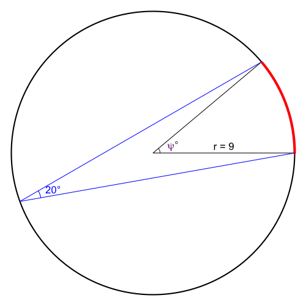

   How long, in centimeters, is the red string? Please answer as a decimal approximation accurate within $\pm 0.01$ centimeters.

#### Question

3. A length of red string is pulled around the circle with radius $r=4$. The red string [subtends](https://en.wikipedia.org/wiki/Subtended_angle) a [central angle](https://en.wikipedia.org/wiki/Central_angle) with a degree measure of $\psi$°, and the red string also subtends an **[inscribed angle](https://en.wikipedia.org/wiki/Inscribed_angle)** with degree measure of 62°.

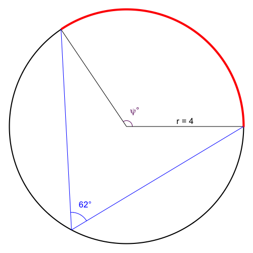

   How long, in centimeters, is the red string? Please answer as a decimal approximation accurate within $\pm 0.01$ centimeters.

#### Question

4. A length of red string is pulled around the circle with radius $r=8$. The red string [subtends](https://en.wikipedia.org/wiki/Subtended_angle) a [central angle](https://en.wikipedia.org/wiki/Central_angle) with a degree measure of $\psi$°, and the red string also subtends an **[inscribed angle](https://en.wikipedia.org/wiki/Inscribed_angle)** with degree measure of 78°.

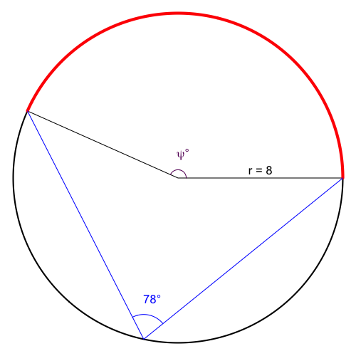

   How long, in centimeters, is the red string? Please answer as a decimal approximation accurate within $\pm 0.01$ centimeters.

#### Question

5. A length of red string is pulled around the circle with radius $r=5$. The red string [subtends](https://en.wikipedia.org/wiki/Subtended_angle) a [central angle](https://en.wikipedia.org/wiki/Central_angle) with a degree measure of $\psi$°, and the red string also subtends an **[inscribed angle](https://en.wikipedia.org/wiki/Inscribed_angle)** with degree measure of 40°.

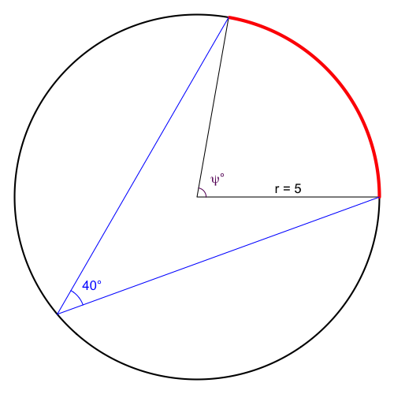

   How long, in centimeters, is the red string? Please answer as a decimal approximation accurate within $\pm 0.01$ centimeters.

#### Question

6. A length of red string is pulled around the circle with radius $r=4$. The red string [subtends](https://en.wikipedia.org/wiki/Subtended_angle) a [central angle](https://en.wikipedia.org/wiki/Central_angle) with a degree measure of $\psi$°, and the red string also subtends an **[inscribed angle](https://en.wikipedia.org/wiki/Inscribed_angle)** with degree measure of 73°.

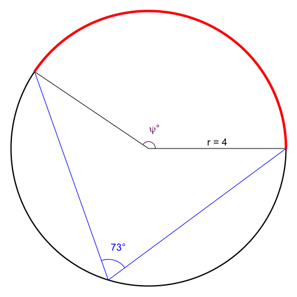

   How long, in centimeters, is the red string? Please answer as a decimal approximation accurate within $\pm 0.01$ centimeters.

#### Question

7. A length of red string is pulled around the circle with radius $r=8$. The red string [subtends](https://en.wikipedia.org/wiki/Subtended_angle) a [central angle](https://en.wikipedia.org/wiki/Central_angle) with a degree measure of $\psi$°, and the red string also subtends an **[inscribed angle](https://en.wikipedia.org/wiki/Inscribed_angle)** with degree measure of 93°.

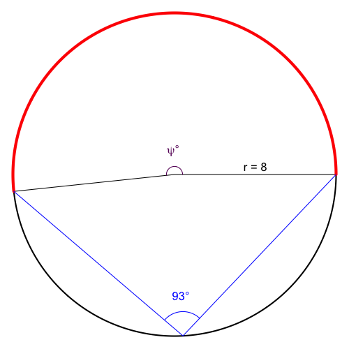

   How long, in centimeters, is the red string? Please answer as a decimal approximation accurate within $\pm 0.01$ centimeters.

#### Question

8. A length of red string is pulled around the circle with radius $r=9$. The red string [subtends](https://en.wikipedia.org/wiki/Subtended_angle) a [central angle](https://en.wikipedia.org/wiki/Central_angle) with a degree measure of $\psi$°, and the red string also subtends an **[inscribed angle](https://en.wikipedia.org/wiki/Inscribed_angle)** with degree measure of 92°.

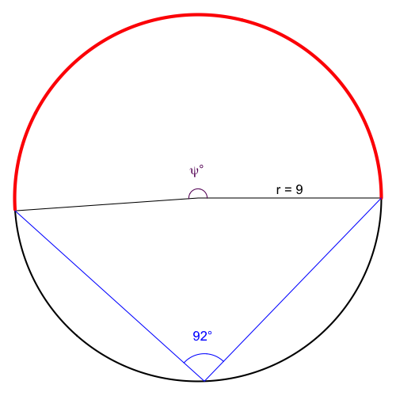

   How long, in centimeters, is the red string? Please answer as a decimal approximation accurate within $\pm 0.01$ centimeters.